# MNIST Digits Classification using Neural Networks

In this part we will implement our first Neural Network! We will use fully connecter Neural Network in order to classify handwritten digits. We will use the well known MNIST dataset. The MNIST database (Modified National Institute of Standards and Technology database) is a large database of handwritten digits that is commonly used for training various image processing systems. The database is also widely used for training and testing in the field of machine learning.

[figure not shown]

## Imports

```python
#importing modules that will be in use
%matplotlib inline
import os
import sys
import numpy as np
import matplotlib.pyplot as plt
from PIL import Image
import random
import time
import copy


import torch
import torch.nn as nn
import torch.nn.functional as F
import torch.optim as optim
import torchvision
from torchvision import datasets, transforms
from torch.utils.data import Dataset, DataLoader
from sklearn.model_selection import train_test_split
```

Mount your drive in order to run locally with colab

```python
from google.colab import drive
drive.mount('/content/drive')
%cd /content/drive/My\ Drive/deepLearning/ex2/FC
from utils import *
```

```
/content/drive/My Drive/deepLearning/ex2/FC
```

**QUESTION 1**: What are the problems with sigmoid?

**ANSWER**:

here we will implement the sigmoid activation function and it's gradient. You should not use any build-in function of sigmoid.

```python
def sigmoid(x):
    # impement the sigmoid funciton
    # ====== YOUR CODE: ======
    sig = 1 / (1 + torch.exp(-x))
    # ========================
    return sig



def softmax(x):
    """
  Softmax loss function, should be implemented in a vectorized fashion (without loops)


  Inputs:
  - X: A torch array of shape (N, C) containing a minibatch of data.
  Returns:
  - probabilities: A torch array of shape (N, C) containing the softmax probabilities.

     """
    #for stability (do not change)
    max_per_row, inds = torch.max(x, dim=1)
    x = (x.T - max_per_row).T

    # ====== YOUR CODE: ======
    exp_x = torch.exp(x)
    sum_exp_x = torch.sum(exp_x, dim=1, keepdim=True)
    probabilities = (exp_x / sum_exp_x).to(device)
    # ========================
    return probabilities
```

Implement a fully-vectorized loss function for the Softmax classifier.

```python
def cross_entropy_error(y, t):
    """
    Inputs:

    - t:  A torch array of shape (N,C) containing  a minibatch of training label. it is a one-hot array,
      with t[GT]=1 and t=0 elsewhere, where GT is the ground truth label ;
    - y: A torch array of shape (N, C) containing the softmax probabilities (the NN's output).

    Returns:
    - loss as single float (do not forget to divide by the number of samples in the minibatch (N))
    """
    # ====== YOUR CODE: ======
    # Compute loss
    N = y.shape[0]
    error = -torch.sum(t * torch.log(y)) / N
    # ========================
    return error
```

```python
def get_accuracy(y,t):
    """
    Computes the accuracy of the NN's predictions.
    Inputs:
    - t:  A torch array of shape (N,C) containing training labels, it is a one-hot array,
      with t[GT]=1 and t=0 elsewhere, where GT is the ground truth label ;
    - y: the torch probabilities for the minibatch (at the end of the forward pass) of shape (N,C)
    Returns:
    - accuracy: a single float of the average accuracy.
    """
    # ====== YOUR CODE: ======
    y_pred = torch.argmax(y, dim=1)
    y_true = torch.argmax(t, dim=1)
    correct = torch.sum(y_pred == y_true).item()
    total = y.shape[0]
    accuracy = correct / total
    # ========================
    return accuracy
```

## Fully-connected Network

We will design and train a two-layer fully-connected neural network with sigmoid nonlinearity and softmax cross entropy loss. We assume an input dimension of D=784, a hidden dimension of H, and perform classification over C classes.

The architecture should be fullyconnected -> sigmoid -> fullyconnected -> softmax.

We will use torch.nn for the linear functions

### config

```python
args={}
args['batch_size']=1000
args['test_batch_size']=1000
args['epochs']=15  #The number of Epochs
args['validation_ratio']=0.15 #The validation ratio from training set
args['eval_every']=1 #Will evaluate the model ever <eval_every> epochs
```

## load the data

```python
device = 'cuda' if torch.cuda.is_available() else 'cpu'
```

```python
def create_train_validation_loaders(dataset: Dataset,
                                         validation_ratio,
                                         batch_size=100):
    """
    Splits a dataset into a train and validation set, returning a
    DataLoader for each.
    :param dataset: The original dataset.
    :param validation_ratio: Ratio (in range 0,1) of the validation set size to
        total dataset size.
    :param batch_size: Batch size the loaders will return from each set.
    :return: A tuple of train, validation and test DataLoader instances.
    """
    if not(0.0 < validation_ratio < 1.0):
        raise ValueError(validation_ratio)


    # TODO: Create two DataLoader instances, dataloader_train and dataloader_valid.
    # They should together represent a train/validation split of the given
    # dataset. Make sure that:
    # 1. Validation set size is validation_ratio * total number of samples.
    # 2. No sample is in both datasets. You can select samples at random
    #    from the dataset.
    # 3. you use shuffle=True in the train dataloader and shuffle=False in the validation dataloder


    # ====== YOUR CODE: ======
    num_train = len(dataset)
    indices = list(range(num_train))
    np.random.shuffle(indices)
    split = int(np.floor(validation_ratio * num_train))
    train_idx, valid_idx = indices[split:], indices[:split]
    train_sampler = torch.utils.data.sampler.SubsetRandomSampler(train_idx)
    valid_sampler = torch.utils.data.sampler.SubsetRandomSampler(valid_idx)
    dl_train = DataLoader(dataset, batch_size=batch_size, shuffle=True)
    dl_valid = DataLoader(dataset, batch_size=batch_size, shuffle=False)
    # ========================

    return dl_train, dl_valid
```

```python
#load the data
dataset = datasets.MNIST('./data', train=True, download=True,
                         transform=transforms.Compose([transforms.ToTensor(),
                                                       transforms.Normalize((0.1307,), (0.3081,))])
                        )

train_loader, val_loader = create_train_validation_loaders(dataset,
                                                           validation_ratio = args['validation_ratio'],
                                                           batch_size= args['batch_size'])
```

```python
test_loader = torch.utils.data.DataLoader(
    datasets.MNIST('./data', train=False, download=True,
                   transform=transforms.Compose([
                       transforms.ToTensor(),
                       transforms.Normalize((0.1307,), (0.3081,))
                   ])),
    batch_size=args['test_batch_size'], shuffle=False)
```

```python
dataloaders = {'training':train_loader,
               'val':val_loader,
               'test':test_loader
              }
```

## Fully connected Neural Network

```python
class FullyConnectedNeuralNetwork(nn.Module):
    #This defines the structure of the NN.
    def __init__(self,
                 hidden_layer_dim
                 ):
      super(FullyConnectedNeuralNetwork, self).__init__()
      # Define the model layers.
      # Use the torch.nn.Linear layers. Set the hidden layer dim to hidden_layer_dim.
      # Notice that the input dim is 784 and the output dim is 10 (number of classes).
      # ====== YOUR CODE: ======
      self.fc1 = nn.Linear(784, hidden_layer_dim).to(device)
      self.sigmoid = sigmoid
      self.fc2 = nn.Linear(hidden_layer_dim, 10).to(device)
      self.softmax = softmax
      # ========================

    def forward(self, x):
      x = torch.flatten(x, start_dim=1,end_dim=-1)
      # ====== YOUR CODE: ======
      x = self.fc1(x)
      x = self.sigmoid(x)
      x = self.fc2(x)
      y = self.softmax(x)
      # ========================
      return y
```

The following functions will train our model

```python
def forward_one_epoch(loader,
                      optimizer,
                      net,
                      mode,
                      progress_bar_str,
                      num_of_epochs
                     ):


    losses, cur_accuracies = [], []
    all_preds,all_targets = [], []
    for batch_idx, (inputs, targets) in enumerate(loader):

        if mode == Mode.training:
            optimizer.zero_grad()

        inputs, targets =inputs.to(device), targets.to(device)
        outputs = net(inputs)
        targets = F.one_hot(targets, num_classes=10)
        loss = cross_entropy_error(outputs, targets)
        losses.append(loss.item())

        if mode == Mode.training:
            #do a step
            loss.backward()
            optimizer.step()

        if len(targets.shape) ==2:
            cur_accuracies.append(get_accuracy(outputs, targets))

        if batch_idx %20 ==0:
            progress_bar(batch_idx, len(loader), progress_bar_str
                   % (num_of_epochs, np.mean(losses), losses[-1], np.mean(cur_accuracies)))

        targets_cpu = targets.cpu().data.numpy()
        outputs_cpu = [i.cpu().data.numpy() for i in outputs]
        outputs_cpu = np.argmax(outputs_cpu, axis=1)

        all_targets.extend(targets_cpu)
        all_preds.extend(outputs_cpu)

        del inputs, targets, outputs
        torch.cuda.empty_cache()


    return losses, cur_accuracies, all_targets, all_preds
```

```python
def train(args, dataloaders):
  seed = 0
  torch.manual_seed(seed)
  if torch.cuda.is_available():
      torch.cuda.manual_seed_all(seed)

  model = FullyConnectedNeuralNetwork(hidden_layer_dim = args['hidden_layer_dim'])
  model = model.to(device)

  optimizer = torch.optim.SGD(model.parameters(), args['lr'])

  training_accuracies, val_accuracies = [], []
  training_losses, val_losses = [], []


  training_loader = dataloaders['training']
  val_loader = dataloaders['val']
  test_loader = dataloaders['test']

  best_acc = -1

  #start training
  for epoch in range(1, args['epochs']+1):

      #training
      model = model.train()

      progress_bar_str = 'Train: repeat %d -- Mean Loss: %.3f | Last Loss: %.3f | Train Acc: %.3f%%'

      losses, cur_training_accuracies, _,_ =  forward_one_epoch(
          loader = training_loader,
          optimizer = optimizer,
          net = model,
          mode = Mode.training,
          progress_bar_str = progress_bar_str,
          num_of_epochs = epoch)


      train_epoch_acc = np.mean(cur_training_accuracies)
      train_epoch_loss= np.mean(losses)
      sys.stdout.flush()
      print()
      print(f'Train epoch {epoch}: accuracy {train_epoch_acc}, loss {train_epoch_loss}', flush=True)
      training_accuracies.append(train_epoch_acc)
      training_losses.append(train_epoch_loss)



      # validation
      model.eval()
      if (epoch-1)%args['eval_every']==0:
          progress_bar_str = 'Validation: repeat %d -- Mean Loss: %.3f | Last Loss: %.3f | val Acc: %.3f%%'

          losses, cur_val_accuracies,_,_ =  forward_one_epoch(val_loader,
                                                                optimizer,
                                                                model,
                                                                Mode.validation,
                                                                progress_bar_str,
                                                                epoch
                                                              )
          val_epoch_acc= np.mean(cur_val_accuracies)
          val_epoch_loss= np.mean(losses)
          sys.stdout.flush()
          val_accuracies.append(val_epoch_acc)

          val_epoch_acc = np.round(val_epoch_acc,3)
          print()
          print(f'Validation epoch {epoch//args["eval_every"]}: accuracy {val_epoch_acc}, loss {val_epoch_loss}', flush=True)
          val_losses.append(val_epoch_loss)

          cur_acc_loss = {
            'training_accuracies':training_accuracies,
            'val_accuracies':val_accuracies,
            'training_losses':training_losses,
            'val_losses':val_losses
                        }

          if best_acc +0.001 < val_epoch_acc:

              best_acc = val_epoch_acc
              best_acc_epoch = epoch

              print(f'========== new best model! epoch {best_acc_epoch}, accuracy {best_acc}  ==========')
              best_model = copy.deepcopy(model)


  progress_bar_str = 'Test: repeat %d -- Mean Loss: %.3f | Last Loss: %.3f | Acc: %.3f%%'
  test_losses, test_cur_test_accuracies, test_all_targets, test_all_preds = forward_one_epoch(test_loader,
                                                                None,
                                                                best_model,
                                                                Mode.test,
                                                                progress_bar_str,
                                                                0)

  test_epoch_acc= np.mean(test_cur_test_accuracies)
  test_epoch_loss= np.mean(test_losses)
  print("===================== Test Results =====================")
  print(f'Test Accuracy : {test_epoch_acc}')
  print(f'Test Loss : {test_epoch_loss}')
  return best_model, cur_acc_loss
```

## Training Process

We will finetune two hyper parameters:

1. The hidden layer dimension.
2. The learning rate.

### Finetuning hidden_layer_dim

#### hidden_layer_dim = 1, lr = 0.0001

Set the hidden_layer_dim to 1 and the lr to 0.0001 and train the model.

```python
args['hidden_layer_dim'] = 1
args['lr']=0.0001
best_model, cur_acc_loss  = train(args, dataloaders)
```

```
Train epoch 1: accuracy 0.10441666666666667, loss 2.5669345895449323

Validation epoch 1: accuracy 0.104, loss 2.5619607170422873
========== new best model! epoch 1, accuracy 0.104  ==========

Train epoch 2: accuracy 0.10441666666666667, loss 2.5572720646858214

Validation epoch 2: accuracy 0.104, loss 2.552495304743449

Train epoch 3: accuracy 0.10441666666666667, loss 2.548031683762868

Validation epoch 3: accuracy 0.104, loss 2.543502231438955

Train epoch 4: accuracy 0.10441666666666667, loss 2.539300497372945

Validation epoch 4: accuracy 0.104, loss 2.535051401456197

Train epoch 5: accuracy 0.10441666666666664, loss 2.5311342159907024

Validation epoch 5: accuracy 0.104, loss 2.5271835764249166

Train epoch 6: accuracy 0.10441666666666667, loss 2.5235599239667255

Validation epoch 6: accuracy 0.104, loss 2.519913077354431

Train epoch 7: accuracy 0.10441666666666667, loss 2.516580899556478

Validation epoch 7: accuracy 0.104, loss 2.5132327596346538

Train epoch 8: accuracy 0.10441666666666666, loss 2.51018031835556

Validation epoch 8: accuracy 0.104, loss 2.5071165283521015

Train epoch 9: accuracy 0.10441666666666666, loss 2.5043285210927326

Validation epoch 9: accuracy 0.104, loss 2.5015313148498537

Train epoch 10: accuracy 0.10441666666666667, loss 2.4989878654479982

Validation epoch 10: accuracy 0.104, loss 2.4964364409446715
```

[output cut: 8 more lines]

```

Train epoch 13: accuracy 0.10441666666666667, loss 2.485609225432078

Validation epoch 13: accuracy 0.104, loss 2.4836655974388124

Train epoch 14: accuracy 0.10441666666666664, loss 2.481893841425578

Validation epoch 14: accuracy 0.104, loss 2.480113379160563

Train epoch 15: accuracy 0.10441666666666667, loss 2.4784879803657534

Validation epoch 15: accuracy 0.104, loss 2.476853291193644
===================== Test Results =====================
Test Accuracy : 0.1028
Test Loss : 2.56939754486084
```

```
Best val accuracy was 0.10441666666666667, at epoch 0
```

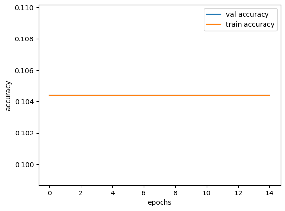

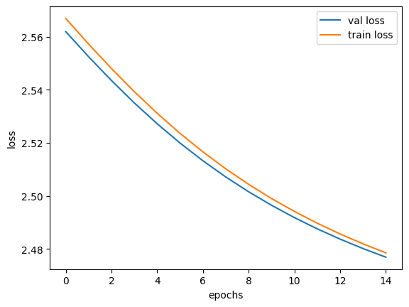

```
0.10441666666666667
```

```python
training_accuracies = cur_acc_loss['training_accuracies']
val_accuracies = cur_acc_loss['val_accuracies']
training_losses = cur_acc_loss['training_losses']
val_losses = cur_acc_loss['val_losses']
plot_graphs(training_accuracies, val_accuracies, training_losses, val_losses)
```

**QUESTION 2.1**: What are the accuracy and loss values? Explain the loss and accuracy graphs.

**ANSWER**:We can see from the graph that the train and validation accuracy started at 0.104 (which is almost 10% which is random) and barely moved, we can also see the loss starting at 2.56 slowly decreasing to 2.48 meaning the model didn't really improve (although it "thought" it did), the reason is that hidden dimension of value 1 can't really handle this "complex" task, it can only handle linear problems which doesn't suit this task.

#### hidden_layer_dim = 5, lr = 0.0001

Set the hidden_layer_dim to 5 and the lr to 0.0001 and train the model.

```python
args['hidden_layer_dim'] = 5
args['lr']=0.0001
best_model, cur_acc_loss  = train(args, dataloaders)
```

```
Train epoch 1: accuracy 0.11250000000000002, loss 2.3580430865287783

Validation epoch 1: accuracy 0.112, loss 2.356839390595754
========== new best model! epoch 1, accuracy 0.112  ==========

Train epoch 2: accuracy 0.11248333333333334, loss 2.355688222249349

Validation epoch 2: accuracy 0.112, loss 2.3545024116834004

Train epoch 3: accuracy 0.11250000000000002, loss 2.353368878364563

Validation epoch 3: accuracy 0.112, loss 2.352201489607493

Train epoch 4: accuracy 0.11248333333333334, loss 2.351085734367371

Validation epoch 4: accuracy 0.112, loss 2.3499369104703267

Train epoch 5: accuracy 0.11249999999999999, loss 2.3488393068313598

Validation epoch 5: accuracy 0.112, loss 2.347709147135417

Train epoch 6: accuracy 0.11253333333333332, loss 2.3466296911239626

Validation epoch 6: accuracy 0.113, loss 2.345518418153127

Train epoch 7: accuracy 0.11254999999999998, loss 2.344457213083903

Validation epoch 7: accuracy 0.113, loss 2.343364723523458

Train epoch 8: accuracy 0.11261666666666666, loss 2.3423216660817463

Validation epoch 8: accuracy 0.113, loss 2.341248067220052

Train epoch 9: accuracy 0.11264999999999999, loss 2.3402231375376386

Validation epoch 9: accuracy 0.113, loss 2.3391681551933288

Train epoch 10: accuracy 0.11271666666666667, loss 2.338161341349284

Validation epoch 10: accuracy 0.113, loss 2.337124991416931
```

[output cut: 8 more lines]

```

Train epoch 13: accuracy 0.11291666666666665, loss 2.332192873954773

Validation epoch 13: accuracy 0.113, loss 2.3312108874320985

Train epoch 14: accuracy 0.11301666666666667, loss 2.3302739461263022

Validation epoch 14: accuracy 0.113, loss 2.3293095072110495

Train epoch 15: accuracy 0.11309999999999999, loss 2.3283892353375752

Validation epoch 15: accuracy 0.113, loss 2.3274420221646626
===================== Test Results =====================
Test Accuracy : 0.11359999999999999
Test Loss : 2.359082293510437
```

```
Best val accuracy was 0.11313333333333335, at epoch 14
```

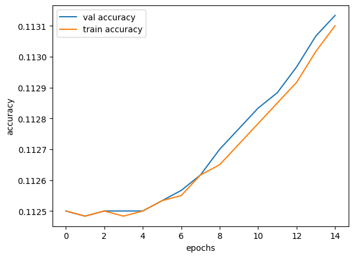

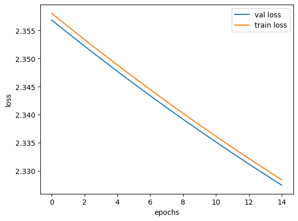

```
0.11313333333333335
```

```python
training_accuracies = cur_acc_loss['training_accuracies']
val_accuracies = cur_acc_loss['val_accuracies']
training_losses = cur_acc_loss['training_losses']
val_losses = cur_acc_loss['val_losses']
plot_graphs(training_accuracies, val_accuracies, training_losses, val_losses)
```

**QUESTION 2.2**: What are the accuracy and loss values? Explain the loss and accuracy graphs.

**ANSWER**: We can see from the graph that the validation accuracy started at 0.112 (which is almost 10% which is random) and very slowly increased to 1.13 which means it barly moved, we can see something similar with the loss starting at 2.35 slowly decreasing to 2.32 meaning the model did improve, but by very little and very slowly. the reason is the learning rate is very low and the hidden layer dimension is very small.

#### hidden_layer_dim = 100, lr = 0.0001

Set the hidden_layer_dim to 100 and the lr to 0.0001 and train the model.

```python
args['hidden_layer_dim'] = 100
args['lr']=0.0001
best_model, cur_acc_loss  = train(args, dataloaders)
```

```
Train epoch 1: accuracy 0.10678333333333336, loss 2.3353135188420615

Validation epoch 1: accuracy 0.107, loss 2.334075073401133
========== new best model! epoch 1, accuracy 0.107  ==========

Train epoch 2: accuracy 0.10788333333333333, loss 2.33289262453715

Validation epoch 2: accuracy 0.109, loss 2.331672179698944
========== new best model! epoch 2, accuracy 0.109  ==========

Train epoch 3: accuracy 0.10931666666666669, loss 2.3305068969726563

Validation epoch 3: accuracy 0.11, loss 2.3293042302131655

Train epoch 4: accuracy 0.11086666666666666, loss 2.328155561288198

Validation epoch 4: accuracy 0.111, loss 2.3269698580106097
========== new best model! epoch 4, accuracy 0.111  ==========

Train epoch 5: accuracy 0.11221666666666666, loss 2.325837218761444

Validation epoch 5: accuracy 0.113, loss 2.3246681094169617
========== new best model! epoch 5, accuracy 0.113  ==========

Train epoch 6: accuracy 0.11384999999999999, loss 2.3235513806343078

Validation epoch 6: accuracy 0.115, loss 2.322398316860199
========== new best model! epoch 6, accuracy 0.115  ==========

Train epoch 7: accuracy 0.11501666666666667, loss 2.3212966402371724

Validation epoch 7: accuracy 0.116, loss 2.320159407456716

Train epoch 8: accuracy 0.11628333333333334, loss 2.319072699546814

Validation epoch 8: accuracy 0.117, loss 2.3179503877957663
========== new best model! epoch 8, accuracy 0.117  ==========

Train epoch 9: accuracy 0.11766666666666666, loss 2.3168779015541077

```

[output cut: 17 more lines]

```

Validation epoch 13: accuracy 0.125, loss 2.307324786980947
========== new best model! epoch 13, accuracy 0.125  ==========

Train epoch 14: accuracy 0.12528333333333333, loss 2.3063183387120563

Validation epoch 14: accuracy 0.126, loss 2.305278178056081

Train epoch 15: accuracy 0.12716666666666668, loss 2.304283698399862

Validation epoch 15: accuracy 0.128, loss 2.3032557129859925
========== new best model! epoch 15, accuracy 0.128  ==========
===================== Test Results =====================
Test Accuracy : 0.1255
Test Loss : 2.306868839263916
```

```
Best val accuracy was 0.12775, at epoch 14
```

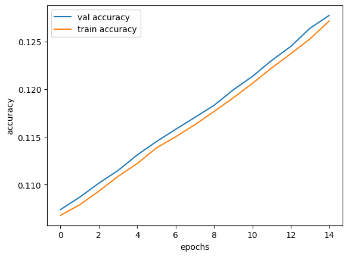

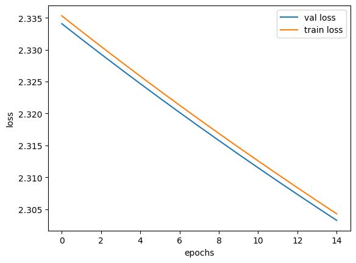

```
0.12775
```

```python
training_accuracies = cur_acc_loss['training_accuracies']
val_accuracies = cur_acc_loss['val_accuracies']
training_losses = cur_acc_loss['training_losses']
val_losses = cur_acc_loss['val_losses']
plot_graphs(training_accuracies, val_accuracies, training_losses, val_losses)
```

**QUESTION 2.3**: What are the accuracy and loss values? Explain the loss and accuracy graphs.

**ANSWER**: The validation accuracy increased from 0.107 to 0.128 and the loss decreased from 2.33 to 2.304, it shows that the model is learning and improving but too slowly, because the learning rate is very small.

#### hidden_layer_dim = 200, lr = 0.0001

Set the hidden_layer_dim to 200 and the lr to 0.0001 and train the model.

```python
args['hidden_layer_dim'] = 200
args['lr']=0.0001
best_model, cur_acc_loss  = train(args, dataloaders)
```

```
Train epoch 1: accuracy 0.14806666666666668, loss 2.3084860682487487

Validation epoch 1: accuracy 0.151, loss 2.3070879936218263
========== new best model! epoch 1, accuracy 0.151  ==========

Train epoch 2: accuracy 0.15404999999999994, loss 2.3057658553123472

Validation epoch 2: accuracy 0.158, loss 2.304404600461324
========== new best model! epoch 2, accuracy 0.158  ==========

Train epoch 3: accuracy 0.16126666666666664, loss 2.303116957346598

Validation epoch 3: accuracy 0.165, loss 2.3017909208933514
========== new best model! epoch 3, accuracy 0.165  ==========

Train epoch 4: accuracy 0.16843333333333332, loss 2.300536398092906

Validation epoch 4: accuracy 0.172, loss 2.2992432634035747
========== new best model! epoch 4, accuracy 0.172  ==========

Train epoch 5: accuracy 0.17575, loss 2.298019023736318

Validation epoch 5: accuracy 0.179, loss 2.296757392088572
========== new best model! epoch 5, accuracy 0.179  ==========

Train epoch 6: accuracy 0.18295, loss 2.2955620686213174

Validation epoch 6: accuracy 0.187, loss 2.2943294564882915
========== new best model! epoch 6, accuracy 0.187  ==========

Train epoch 7: accuracy 0.19043333333333334, loss 2.2931614995002745

Validation epoch 7: accuracy 0.194, loss 2.2919562617937723
========== new best model! epoch 7, accuracy 0.194  ==========

Train epoch 8: accuracy 0.19783333333333336, loss 2.2908137679100036

Validation epoch 8: accuracy 0.201, loss 2.289634867509206
========== new best model! epoch 8, accuracy 0.201  ==========

```

[output cut: 22 more lines]

```
Validation epoch 13: accuracy 0.23, loss 2.2787014404932657
========== new best model! epoch 13, accuracy 0.23  ==========

Train epoch 14: accuracy 0.23195, loss 2.2776843587557476

Validation epoch 14: accuracy 0.234, loss 2.2766321380933126
========== new best model! epoch 14, accuracy 0.234  ==========

Train epoch 15: accuracy 0.23553333333333332, loss 2.2756314873695374

Validation epoch 15: accuracy 0.238, loss 2.2745967904726663
========== new best model! epoch 15, accuracy 0.238  ==========
===================== Test Results =====================
Test Accuracy : 0.2444
Test Loss : 2.273361611366272
```

```
Best val accuracy was 0.2379666666666667, at epoch 14
```

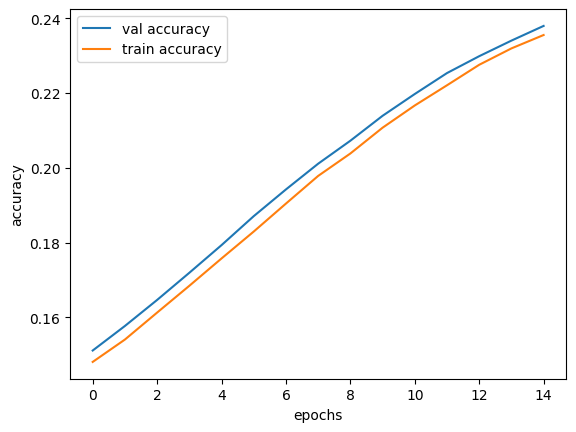

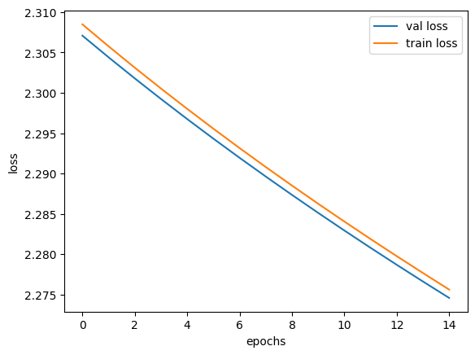

```
0.2379666666666667
```

```python
training_accuracies = cur_acc_loss['training_accuracies']
val_accuracies = cur_acc_loss['val_accuracies']
training_losses = cur_acc_loss['training_losses']
val_losses = cur_acc_loss['val_losses']
plot_graphs(training_accuracies, val_accuracies, training_losses, val_losses)
```

**QUESTION 2.4**: What are the accuracy and loss values? Explain the loss and accuracy graphs.

**ANSWER**:The validation accuracy increased from 0.151 to 0.238 and the loss decreased from 2.30 to 2.27, it shows that the model is learning and improving but too slowly, because the learning rate very small.

### Finetuning learning rate

#### hidden_layer_dim = 100, lr = 0.000001

Set the hidden_layer_dim to 100 and the lr to 0.000001 and train the model.

```python
args['hidden_layer_dim'] = 100
args['lr']=0.000001
best_model, cur_acc_loss  = train(args, dataloaders)
```

```
Train epoch 1: accuracy 0.10601666666666666, loss 2.3365017334620157

Validation epoch 1: accuracy 0.106, loss 2.3364893953005472
========== new best model! epoch 1, accuracy 0.106  ==========

Train epoch 2: accuracy 0.10603333333333334, loss 2.3364774505297343

Validation epoch 2: accuracy 0.106, loss 2.336465052763621

Train epoch 3: accuracy 0.10603333333333334, loss 2.336453131834666

Validation epoch 3: accuracy 0.106, loss 2.336440718173981

Train epoch 4: accuracy 0.10606666666666668, loss 2.3364288131395976

Validation epoch 4: accuracy 0.106, loss 2.336416411399841

Train epoch 5: accuracy 0.10606666666666667, loss 2.336404474576314

Validation epoch 5: accuracy 0.106, loss 2.3363921006520587

Train epoch 6: accuracy 0.1061, loss 2.336380151907603

Validation epoch 6: accuracy 0.106, loss 2.3363677899042767

Train epoch 7: accuracy 0.10611666666666666, loss 2.3363558451334634

Validation epoch 7: accuracy 0.106, loss 2.336343506971995

Train epoch 8: accuracy 0.10613333333333336, loss 2.336331554253896

Validation epoch 8: accuracy 0.106, loss 2.336319168408712

Train epoch 9: accuracy 0.10615, loss 2.3363072554270428

Validation epoch 9: accuracy 0.106, loss 2.336294913291931

Train epoch 10: accuracy 0.10616666666666667, loss 2.3362829605738322

Validation epoch 10: accuracy 0.106, loss 2.336270598570506
```

[output cut: 8 more lines]

```

Train epoch 13: accuracy 0.10621666666666668, loss 2.336210083961487

Validation epoch 13: accuracy 0.106, loss 2.3361977140108743

Train epoch 14: accuracy 0.10621666666666667, loss 2.3361857891082765

Validation epoch 14: accuracy 0.106, loss 2.336173431078593

Train epoch 15: accuracy 0.10624999999999998, loss 2.336161514123281

Validation epoch 15: accuracy 0.106, loss 2.3361491719881693
===================== Test Results =====================
Test Accuracy : 0.10619999999999999
Test Loss : 2.3410537958145143
```

```
Best val accuracy was 0.10628333333333333, at epoch 14
```

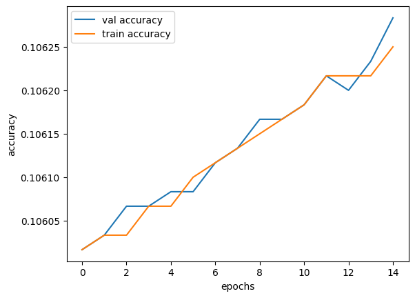

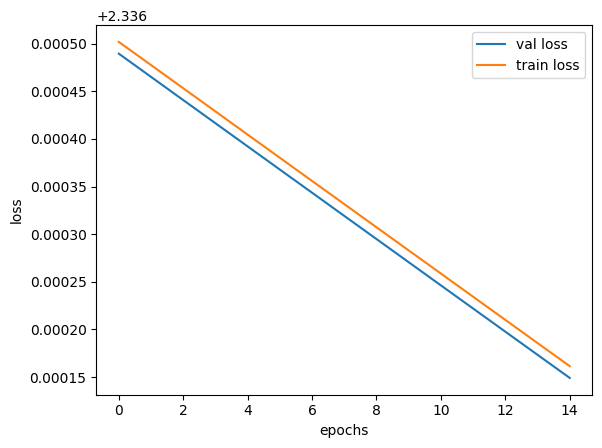

```
0.10628333333333333
```

```python
training_accuracies = cur_acc_loss['training_accuracies']
val_accuracies = cur_acc_loss['val_accuracies']
training_losses = cur_acc_loss['training_losses']
val_losses = cur_acc_loss['val_losses']
plot_graphs(training_accuracies, val_accuracies, training_losses, val_losses)
```

**QUESTION 3.1**: What are the accuracy and loss values? Explain the loss and accuracy graphs.

accuracy 0.106, loss 2.3364

#### hidden_layer_dim = 100, lr = 0.1

```python
args['hidden_layer_dim'] = 100
args['lr']= 0.1
best_model, cur_acc_loss  = train(args, dataloaders)
```

```
Train epoch 1: accuracy 0.6349166666666667, loss 1.6954855799674988

Validation epoch 1: accuracy 0.778, loss 1.1591716508070629
========== new best model! epoch 1, accuracy 0.778  ==========

Train epoch 2: accuracy 0.8145333333333333, loss 0.908364396293958

Validation epoch 2: accuracy 0.846, loss 0.7280741930007935
========== new best model! epoch 2, accuracy 0.846  ==========

Train epoch 3: accuracy 0.8599666666666667, loss 0.6359459012746811

Validation epoch 3: accuracy 0.871, loss 0.5608908116817475
========== new best model! epoch 3, accuracy 0.871  ==========

Train epoch 4: accuracy 0.8783833333333332, loss 0.5153459628423055

Validation epoch 4: accuracy 0.885, loss 0.475398484369119
========== new best model! epoch 4, accuracy 0.885  ==========

Train epoch 5: accuracy 0.8881333333333334, loss 0.4490025475621223

Validation epoch 5: accuracy 0.892, loss 0.4246440201997757
========== new best model! epoch 5, accuracy 0.892  ==========

Train epoch 6: accuracy 0.8944666666666667, loss 0.4075063223640124

Validation epoch 6: accuracy 0.897, loss 0.3911333178480466
========== new best model! epoch 6, accuracy 0.897  ==========

Train epoch 7: accuracy 0.8991833333333333, loss 0.3790437097350756

Validation epoch 7: accuracy 0.901, loss 0.3667077459394932
========== new best model! epoch 7, accuracy 0.901  ==========

Train epoch 8: accuracy 0.90265, loss 0.357995809117953

Validation epoch 8: accuracy 0.905, loss 0.34854773730039595
========== new best model! epoch 8, accuracy 0.905  ==========

```

[output cut: 20 more lines]

```

Validation epoch 13: accuracy 0.917, loss 0.29460290099183717
========== new best model! epoch 13, accuracy 0.917  ==========

Train epoch 14: accuracy 0.9170833333333334, loss 0.29160856107870736

Validation epoch 14: accuracy 0.918, loss 0.28738704323768616

Train epoch 15: accuracy 0.9190666666666668, loss 0.28477176080147426

Validation epoch 15: accuracy 0.92, loss 0.28088042040665945
========== new best model! epoch 15, accuracy 0.92  ==========
===================== Test Results =====================
Test Accuracy : 0.9238
Test Loss : 0.27321675717830657
```

```
Best val accuracy was 0.9198166666666665, at epoch 14
```

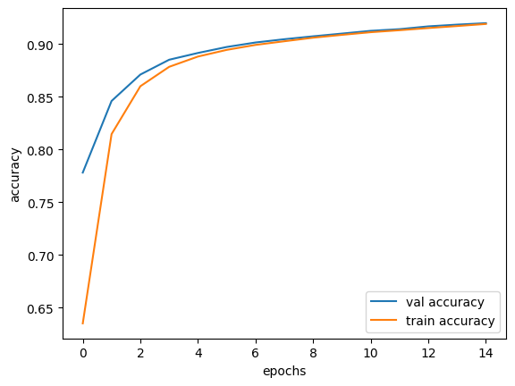

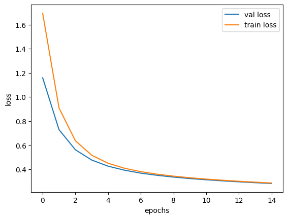

```
0.9198166666666665
```

```python
training_accuracies = cur_acc_loss['training_accuracies']
val_accuracies = cur_acc_loss['val_accuracies']
training_losses = cur_acc_loss['training_losses']
val_losses = cur_acc_loss['val_losses']
plot_graphs(training_accuracies, val_accuracies, training_losses, val_losses)
```

**QUESTION 3.2**: What are the accuracy and loss values? Explain the loss and accuracy graphs.

#### hidden_layer_dim = 100, lr = 0.001

Set the hidden_layer_dim to 100 and the lr to 0.001 and train the model.

```python
args['hidden_layer_dim'] = 100
args['lr']=0.001
best_model, cur_acc_loss  = train(args, dataloaders)
```

```
Train epoch 1: accuracy 0.11263333333333335, loss 2.3249956568082175

Validation epoch 1: accuracy 0.12, loss 2.313594349225362
========== new best model! epoch 1, accuracy 0.12  ==========

Train epoch 2: accuracy 0.12755, loss 2.303511687119802

Validation epoch 2: accuracy 0.135, loss 2.293452489376068
========== new best model! epoch 2, accuracy 0.135  ==========

Train epoch 3: accuracy 0.1436166666666667, loss 2.284439794222514

Validation epoch 3: accuracy 0.154, loss 2.2753817598025003
========== new best model! epoch 3, accuracy 0.154  ==========

Train epoch 4: accuracy 0.1624166666666667, loss 2.267147962252299

Validation epoch 4: accuracy 0.173, loss 2.2588191986083985
========== new best model! epoch 4, accuracy 0.173  ==========

Train epoch 5: accuracy 0.18406666666666668, loss 2.2511621793111165

Validation epoch 5: accuracy 0.196, loss 2.2433709303538003
========== new best model! epoch 5, accuracy 0.196  ==========

Train epoch 6: accuracy 0.21704999999999997, loss 2.236139194170634

Validation epoch 6: accuracy 0.245, loss 2.2287415862083435
========== new best model! epoch 6, accuracy 0.245  ==========

Train epoch 7: accuracy 0.27773333333333333, loss 2.221808648109436

Validation epoch 7: accuracy 0.311, loss 2.2146909991900126
========== new best model! epoch 7, accuracy 0.311  ==========

Train epoch 8: accuracy 0.34295000000000003, loss 2.2079747200012205

Validation epoch 8: accuracy 0.374, loss 2.2010530471801757
========== new best model! epoch 8, accuracy 0.374  ==========

```

[output cut: 22 more lines]

```
Validation epoch 13: accuracy 0.517, loss 2.135772220293681
========== new best model! epoch 13, accuracy 0.517  ==========

Train epoch 14: accuracy 0.5238333333333334, loss 2.1294795870780945

Validation epoch 14: accuracy 0.53, loss 2.1229410727818805
========== new best model! epoch 14, accuracy 0.53  ==========

Train epoch 15: accuracy 0.5357333333333333, loss 2.1166545311609903

Validation epoch 15: accuracy 0.541, loss 2.1101195017496743
========== new best model! epoch 15, accuracy 0.541  ==========
===================== Test Results =====================
Test Accuracy : 0.5451999999999999
Test Loss : 2.108898162841797
```

```
Best val accuracy was 0.5413166666666667, at epoch 14
```

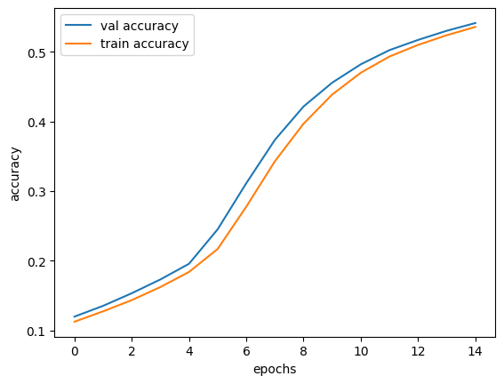

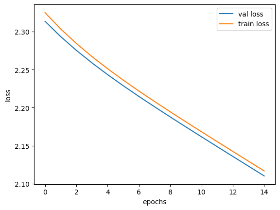

```
0.5413166666666667
```

```python
training_accuracies = cur_acc_loss['training_accuracies']
val_accuracies = cur_acc_loss['val_accuracies']
training_losses = cur_acc_loss['training_losses']
val_losses = cur_acc_loss['val_losses']
plot_graphs(training_accuracies, val_accuracies, training_losses, val_losses)
```

**QUESTION 3.3**: What are the accuracy and loss values? Explain the loss and accuracy graphs.

**ANSWER**:The validation accuracy increased from 0.12 to 0.541 The loss decreased from 2.313 to 2.11.

**QUESTION 4:** : Suggest a way to improve the results by changing the networks's architecture

**ANSWER**: We can make the model deeper and more complex by adding additional hidden layers, and by that the model will be able to capture more complex patterns in those pictures (correlating more then 2 pixels at a time).

## Explainability

Here we will plot some of the network weights. **Be sure you run this cell with your best model!**

```
(784, 100)
```

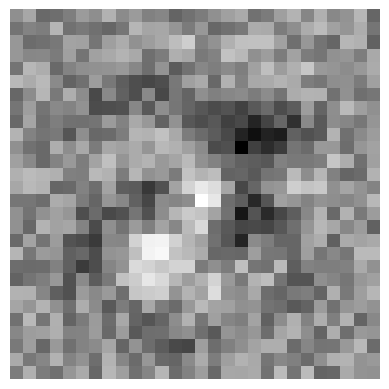

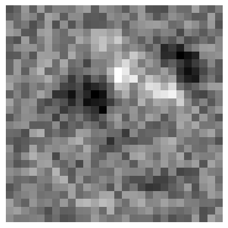

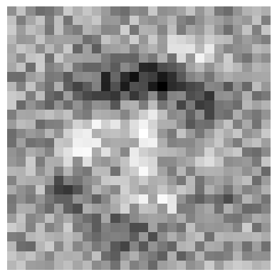

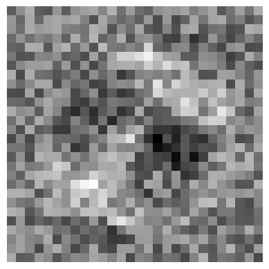

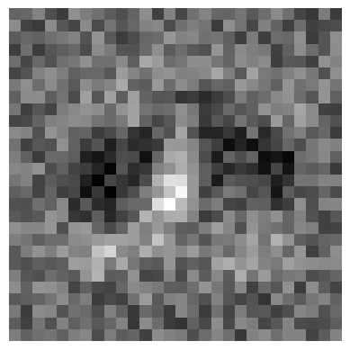

```python
# Visualize some weights. features of digits should be somehow present.
def show_net_weights(net_params):
    W1 = net_params.fc1.weight.cpu().data.numpy().T
    print(W1.shape)
    for i in range(5):
        W = W1[:,i*5].reshape(28, 28)
        plt.imshow(W,cmap='gray')
        plt.axis('off')
        plt.show()

show_net_weights(best_model)
```

**QUESTION 5:** Where are the bright regions? why?

**ANSWER:** Mostly in the middle regions, the brighter pixels repressenting positive weights, weights that "pull hard" to specific classes, so the reason is probably because this area is the most importent for this model in determining the digit (the model "guess").